# Cross-implementation validation of Joint-RPCA

Comparison of mia and Gemelli using paired IBDMDB MGX–MTX data

# Study objective

This notebook evaluates whether the Joint-RPCA implementation in the development version of `mia` reproduces the numerical structure obtained with Gemelli when both implementations are applied to the same paired MGX and MTX data, use the same train–test split, and estimate the same number of latent components.

Agreement is evaluated at five levels:

1. sample coordinates in the Joint-RPCA space;
2. feature loadings;
3. proportion of variation explained;
4. cross-validation error trajectories; and
5. pairwise sample distances.

# Interpretation guide

# Software provenance

**Show analysis code**

```r
`%||%` <- function(x, fallback = NA_character_) {
  if (is.null(x) || length(x) == 0L || is.na(x)) fallback else x
}

mia_info <- packageDescription("mia")

mia_provenance <- data.frame(
  item = c(
    "mia version",
    "mia repository",
    "mia branch",
    "mia commit",
    "R version",
    "Platform"
  ),
  value = c(
    mia_info[["Version"]],
    paste0(
      mia_info[["RemoteUsername"]] %||% "microbiome",
      "/",
      mia_info[["RemoteRepo"]] %||% "mia"
    ),
    mia_info[["RemoteRef"]] %||% "devel",
    mia_info[["RemoteSha"]] %||% "not recorded",
    R.version.string,
    R.version$platform
  ),
  stringsAsFactors = FALSE
)

knitr::kable(mia_provenance)
```

| item | value |
| --- | --- |
| mia version | 1.21.3 |
| mia repository | microbiome/mia |
| mia branch | devel |
| mia commit | fcd07419d8f9e4a1810f6d0a7ab7fe3b218bcaa3 |
| R version | R version 4.5.1 (2025-06-13 ucrt) |
| Platform | x86_64-w64-mingw32 |

**Show analysis code**

```r
if (!file.exists(required_python_outputs[1])) {
  stop(
    "Python provenance is missing. Run: python python/export_python_versions.py",
    call. = FALSE
  )
}

python_versions <- jsonlite::read_json(
  required_python_outputs[1],
  simplifyVector = TRUE
)

python_provenance <- data.frame(
  software = names(python_versions),
  version = unname(unlist(python_versions)),
  stringsAsFactors = FALSE
)

knitr::kable(python_provenance)
```

| software | version |
| --- | --- |
| python | 3.8.20 \| packaged by conda-forge \| (default, Sep 30 2024, 17:52:49) |
| [GCC 13.3.0] |  |
| platform | Linux-6.6.114.1-microsoft-standard-WSL2-x86_64-with-glibc2.17 |
| gemelli | 0.0.12 |
| numpy | 1.23.5 |
| scipy | 1.10.1 |
| pandas | 2.0.3 |
| biom | 2.1.13 |
| scikit_bio | 0.5.9 |

# Data preparation

**Show analysis code**

```r
data("ibdmdb", package = "mia")
mae <- ibdmdb

stopifnot(methods::is(mae, "MultiAssayExperiment"))
stopifnot(all(c("MGX", "MTX") %in% names(mae)))

mae <- MultiAssayExperiment::intersectColumns(mae)

mgx <- SummarizedExperiment::assay(mae[["MGX"]], "mgx")
mtx <- SummarizedExperiment::assay(mae[["MTX"]], "mtx")

stopifnot(
  identical(colnames(mgx), colnames(mtx)),
  all(is.finite(mgx)),
  all(is.finite(mtx)),
  all(mgx >= 0),
  all(mtx >= 0)
)
```

**Show analysis code**

```r
rownames(mgx) <- paste0("MGX::", make.unique(rownames(mgx)))
rownames(mtx) <- paste0("MTX::", make.unique(rownames(mtx)))

rownames(mae[["MGX"]]) <- rownames(mgx)
rownames(mae[["MTX"]]) <- rownames(mtx)

stopifnot(anyDuplicated(c(rownames(mgx), rownames(mtx))) == 0L)

sample_ids <- colnames(mgx)

dataset_summary <- data.frame(
  modality = c("MGX", "MTX"),
  samples = c(ncol(mgx), ncol(mtx)),
  features = c(nrow(mgx), nrow(mtx)),
  zero_fraction = c(mean(mgx == 0), mean(mtx == 0))
)

dataset_summary$zero_fraction <- percent(
  dataset_summary$zero_fraction,
  accuracy = 0.1
)

names(dataset_summary) <- c(
  "Modality",
  "Samples",
  "Features",
  "Zero entries"
)

knitr::kable(
  dataset_summary,
  caption = "Characteristics of the two input assays",
  align = c("l", "r", "r", "r")
)
```

Characteristics of the two input assays

| Modality | Samples | Features | Zero entries |
| --- | --- | --- | --- |
| MGX | 60 | 459 | 62.2% |
| MTX | 60 | 800 | 30.9% |

# Export of common inputs

**Show analysis code**

```r
dir.create("data", recursive = TRUE, showWarnings = FALSE)
dir.create("results/mia", recursive = TRUE, showWarnings = FALSE)

write.csv(mgx, "data/mgx_raw.csv", quote = TRUE)
write.csv(mtx, "data/mtx_raw.csv", quote = TRUE)

set.seed(analysis_seed)
n_test <- max(1L, floor(0.20 * length(sample_ids)))
test_ids <- sort(sample(sample_ids, size = n_test, replace = FALSE))

split_df <- data.frame(
  sample_id = sample_ids,
  train_test = ifelse(sample_ids %in% test_ids, "test", "train"),
  stringsAsFactors = FALSE
)

write.csv(
  split_df,
  "data/train_test_split.csv",
  row.names = FALSE,
  quote = FALSE
)

stopifnot(
  file.exists("data/mgx_raw.csv"),
  file.exists("data/mtx_raw.csv"),
  file.exists("data/train_test_split.csv")
)

knitr::kable(as.data.frame(table(split_df$train_test)), col.names = c("Set", "Samples"))
```

| Set | Samples |
| --- | --- |
| test | 12 |
| train | 48 |

# Joint-RPCA in R

**Show analysis code**

```r
mae_rclr <- mae

mae_rclr[["MGX"]] <- transformAssay(
  mae_rclr[["MGX"]],
  assay.type = "mgx",
  method = "rclr",
  impute = FALSE,
  name = "rclr"
)

mae_rclr[["MTX"]] <- transformAssay(
  mae_rclr[["MTX"]],
  assay.type = "mtx",
  method = "rclr",
  impute = FALSE,
  name = "rclr"
)

stopifnot(
  "rclr" %in% SummarizedExperiment::assayNames(mae_rclr[["MGX"]]),
  "rclr" %in% SummarizedExperiment::assayNames(mae_rclr[["MTX"]])
)
```

**Show analysis code**

```r
set.seed(analysis_seed)

mia_result <- mia::getJointRPCA(
  mae_rclr,
  experiments = c("MGX", "MTX"),
  assay.types = c("rclr", "rclr"),
  test.set = test_ids,
  ncomponents = n_components,
  max.iterations = max_iterations
)

mia_sample_scores <- as.matrix(mia_result)
mia_feature_loadings <- attr(mia_result, "rotation")
mia_proportion_explained <- as.numeric(attr(mia_result, "percentVar")) / 100
mia_distance <- as.matrix(dist(mia_sample_scores))

stopifnot(
  !anyNA(mia_sample_scores),
  nrow(mia_sample_scores) == length(sample_ids),
  ncol(mia_sample_scores) == n_components,
  ncol(mia_feature_loadings) == n_components
)

write.csv(mia_sample_scores, "results/mia/sample_scores.csv", quote = TRUE)
write.csv(mia_feature_loadings, "results/mia/feature_loadings.csv", quote = TRUE)
saveRDS(mia_result, "results/mia/mia_result.rds")
```

# Gemelli results

**Show analysis code**

```r
missing_python_outputs <- required_python_outputs[!file.exists(required_python_outputs)]

if (length(missing_python_outputs) > 0L) {
  stop(
    "Gemelli outputs are missing: ",
    paste(missing_python_outputs, collapse = ", "),
    ". Run in WSL: python python/run_gemelli.py",
    call. = FALSE
  )
}

gemelli_sample_scores_raw <- as.matrix(read.csv(
  required_python_outputs[2],
  row.names = 1,
  check.names = FALSE
))

gemelli_feature_loadings_raw <- as.matrix(read.csv(
  required_python_outputs[3],
  row.names = 1,
  check.names = FALSE
))

gemelli_proportion_raw <- read.csv(
  required_python_outputs[4],
  row.names = 1,
  check.names = FALSE
)

gemelli_distance <- as.matrix(read.csv(
  required_python_outputs[5],
  row.names = 1,
  check.names = FALSE
))

gemelli_cv_error <- read.csv(
  required_python_outputs[6],
  row.names = 1,
  check.names = FALSE
)

mia_cv_error <- as.data.frame(attr(mia_result, "cv_error"))

stopifnot(
  setequal(rownames(mia_sample_scores), rownames(gemelli_sample_scores_raw)),
  setequal(rownames(mia_feature_loadings), rownames(gemelli_feature_loadings_raw)),
  nrow(mia_cv_error) > 0L,
  nrow(gemelli_cv_error) > 0L
)
```

# Alignment of components

**Show analysis code**

```r
gemelli_sample_scores_raw <- gemelli_sample_scores_raw[
  rownames(mia_sample_scores),
  ,
  drop = FALSE
]

gemelli_feature_loadings_raw <- gemelli_feature_loadings_raw[
  rownames(mia_feature_loadings),
  ,
  drop = FALSE
]

component_correlations <- abs(cor(
  mia_sample_scores,
  gemelli_sample_scores_raw
))

permutations <- rbind(
  c(1L, 2L, 3L),
  c(1L, 3L, 2L),
  c(2L, 1L, 3L),
  c(2L, 3L, 1L),
  c(3L, 1L, 2L),
  c(3L, 2L, 1L)
)

permutation_scores <- apply(permutations, 1L, function(p) {
  sum(component_correlations[cbind(seq_len(n_components), p)])
})

best_permutation <- permutations[which.max(permutation_scores), ]

gemelli_sample_scores <- gemelli_sample_scores_raw[, best_permutation, drop = FALSE]
gemelli_feature_loadings <- gemelli_feature_loadings_raw[, best_permutation, drop = FALSE]
gemelli_proportion_explained <- as.numeric(gemelli_proportion_raw[, 1])[best_permutation]

for (j in seq_len(n_components)) {
  if (sum(mia_sample_scores[, j] * gemelli_sample_scores[, j]) < 0) {
    gemelli_sample_scores[, j] <- -gemelli_sample_scores[, j]
    gemelli_feature_loadings[, j] <- -gemelli_feature_loadings[, j]
  }
}

colnames(gemelli_sample_scores) <- colnames(mia_sample_scores)
colnames(gemelli_feature_loadings) <- colnames(mia_feature_loadings)
```

# Results

## Overall agreement summary

The following sections quantify agreement separately for each output of the Joint-RPCA workflow. Sample scores are first aligned for component order, sign, and component-specific scale. Feature loadings are aligned using the same component order and sign convention.

**Show analysis code**

```r
extract_cv_column <- function(x, candidates) {
  matched <- intersect(candidates, names(x))
  if (length(matched) == 0L) {
    stop(
      "Could not identify a CV column. Available columns: ",
      paste(names(x), collapse = ", "),
      call. = FALSE
    )
  }
  as.numeric(x[[matched[1]]])
}

spearman_label <- function(x, y) {
  test <- suppressWarnings(
    cor.test(x, y, method = "spearman", exact = FALSE)
  )

  rho <- unname(test$estimate)
  p_value <- test$p.value

  paste0(
    "Spearman rho=", format(round(rho, 4), nsmall = 1),
    ", p=", format(p_value, scientific = TRUE, digits = 2)
  )
}
```

## Sample scores

**Show analysis code**

```r
# Component-specific scaling accounts for differing score normalization.
gemelli_scores_scaled <- gemelli_sample_scores
scale_factors <- numeric(n_components)

for (j in seq_len(n_components)) {
  scale_factors[j] <- sum(
    mia_sample_scores[, j] * gemelli_sample_scores[, j]
  ) / sum(gemelli_sample_scores[, j]^2)

  gemelli_scores_scaled[, j] <- gemelli_sample_scores[, j] * scale_factors[j]
}

pc_correlations <- diag(cor(mia_sample_scores, gemelli_sample_scores))
sample_score_table <- data.frame(
  Component = colnames(mia_sample_scores),
  `Pearson correlation` = pc_correlations,
  `mia SD` = apply(mia_sample_scores, 2, sd),
  `Gemelli SD before scaling` = apply(gemelli_sample_scores, 2, sd),
  `Applied scale factor` = scale_factors,
  check.names = FALSE
)

knitr::kable(
  sample_score_table,
  digits = 6,
  caption = paste(
    "Component-wise agreement of sample scores.",
    "Gemelli scores are shown before component-specific rescaling."
  ),
  align = c("l", "r", "r", "r", "r")
)
```

Component-wise agreement of sample scores. Gemelli scores are shown before component-specific rescaling.

|  | Component | Pearson correlation | mia SD | Gemelli SD before scaling | Applied scale factor |
| --- | --- | --- | --- | --- | --- |
| PC1 | PC1 | 1 | 0.135109 | 0.135110 | 0.999998 |
| PC2 | PC2 | 1 | 0.144043 | 0.144044 | 0.999994 |
| PC3 | PC3 | 1 | 0.139205 | 0.139205 | 0.999996 |

**Show analysis code**

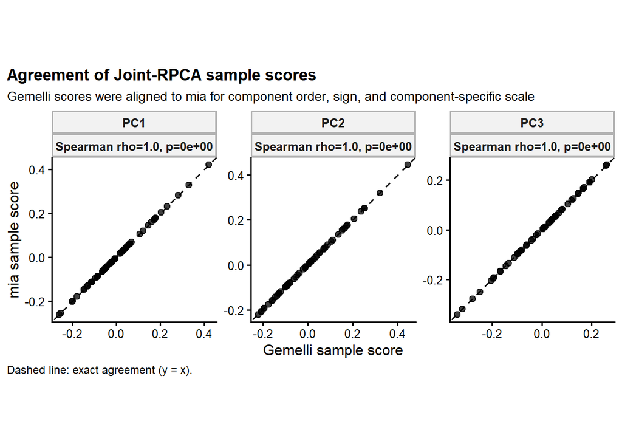

```r
sample_plot_data <- do.call(rbind, lapply(seq_len(n_components), function(j) {
  python_values <- gemelli_scores_scaled[, j]
  r_values <- mia_sample_scores[, j]

  data.frame(
    panel = spearman_label(python_values, r_values),
    component = paste0("PC", j),
    Python = python_values,
    R = r_values
  )
}))

ggplot(sample_plot_data, aes(x = Python, y = R)) +
  geom_abline(
    intercept = 0,
    slope = 1,
    linewidth = 0.55,
    linetype = "dashed"
  ) +
  geom_point(size = 2.1, alpha = 0.75) +
  facet_wrap(
    vars(component, panel),
    scales = "free",
    nrow = 1,
    labeller = label_value
  ) +
  labs(
    title = "Agreement of Joint-RPCA sample scores",
    subtitle = paste(
      "Gemelli scores were aligned to mia for component order, sign,",
      "and component-specific scale"
    ),
    x = "Gemelli sample score",
    y = "mia sample score",
    caption = "Dashed line: exact agreement (y = x)."
  ) +
  theme(aspect.ratio = 1)
```

## Feature loadings

**Show analysis code**

```r
feature_loading_correlations <- diag(cor(
  mia_feature_loadings,
  gemelli_feature_loadings
))

feature_loading_table <- data.frame(
  Component = paste0("PC", seq_len(n_components)),
  `Pearson correlation` = feature_loading_correlations,
  check.names = FALSE
)

knitr::kable(
  feature_loading_table,
  digits = 6,
  caption = "Component-wise agreement of feature loadings",
  align = c("l", "r")
)
```

Component-wise agreement of feature loadings

|  | Component | Pearson correlation |
| --- | --- | --- |
| PC1 | PC1 | 1 |
| PC2 | PC2 | 1 |
| PC3 | PC3 | 1 |

**Show analysis code**

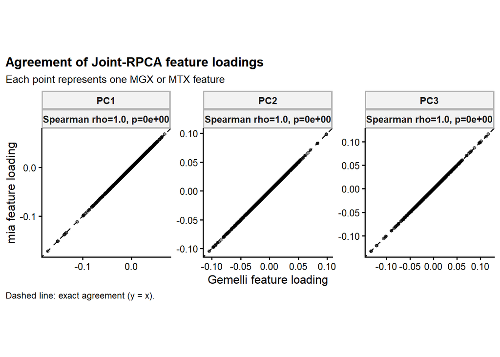

```r
feature_plot_data <- do.call(rbind, lapply(seq_len(n_components), function(j) {
  python_values <- gemelli_feature_loadings[, j]
  r_values <- mia_feature_loadings[, j]

  data.frame(
    panel = spearman_label(python_values, r_values),
    component = paste0("PC", j),
    Python = python_values,
    R = r_values
  )
}))

ggplot(feature_plot_data, aes(x = Python, y = R)) +
  geom_abline(
    intercept = 0,
    slope = 1,
    linewidth = 0.55,
    linetype = "dashed"
  ) +
  geom_point(size = 1.15, alpha = 0.45) +
  facet_wrap(
    vars(component, panel),
    scales = "free",
    nrow = 1,
    labeller = label_value
  ) +
  labs(
    title = "Agreement of Joint-RPCA feature loadings",
    subtitle = "Each point represents one MGX or MTX feature",
    x = "Gemelli feature loading",
    y = "mia feature loading",
    caption = "Dashed line: exact agreement (y = x)."
  ) +
  theme(aspect.ratio = 1)
```

## Proportion explained

**Show analysis code**

```r
explained_variance_comparison <- data.frame(
  Component = paste0("PC", seq_len(n_components)),
  Gemelli = gemelli_proportion_explained,
  mia = mia_proportion_explained,
  check.names = FALSE
)

explained_variance_comparison$`Absolute difference` <- abs(
  explained_variance_comparison$Gemelli -
    explained_variance_comparison$mia
)

display_explained_variance <- explained_variance_comparison
display_explained_variance$Gemelli <- percent(
  display_explained_variance$Gemelli,
  accuracy = 0.01
)
display_explained_variance$mia <- percent(
  display_explained_variance$mia,
  accuracy = 0.01
)
display_explained_variance$`Absolute difference` <- percent(
  display_explained_variance$`Absolute difference`,
  accuracy = 0.0001
)

knitr::kable(
  display_explained_variance,
  caption = "Proportion of variation explained by each component",
  align = c("l", "r", "r", "r")
)
```

Proportion of variation explained by each component

| Component | Gemelli | mia | Absolute difference |
| --- | --- | --- | --- |
| PC1 | 100.00% | 100.00% | 0.0000% |
| PC2 | 0.00% | 0.00% | 0.0000% |
| PC3 | 0.00% | 0.00% | 0.0000% |

**Show analysis code**

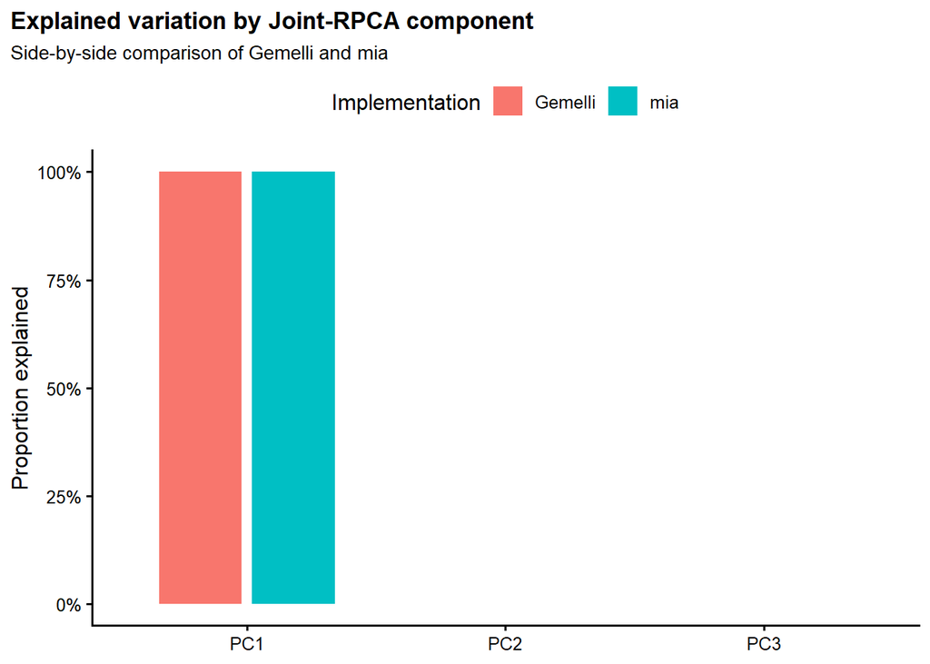

```r
explained_plot_data <- rbind(
  data.frame(
    Component = explained_variance_comparison$Component,
    Implementation = "Gemelli",
    Proportion = explained_variance_comparison$Gemelli
  ),
  data.frame(
    Component = explained_variance_comparison$Component,
    Implementation = "mia",
    Proportion = explained_variance_comparison$mia
  )
)

ggplot(
  explained_plot_data,
  aes(x = Component, y = Proportion, fill = Implementation)
) +
  geom_col(
    position = position_dodge(width = 0.72),
    width = 0.64
  ) +
  scale_y_continuous(labels = percent_format(accuracy = 1)) +
  labs(
    title = "Explained variation by Joint-RPCA component",
    subtitle = "Side-by-side comparison of Gemelli and mia",
    x = NULL,
    y = "Proportion explained"
  )
```

## Cross-validation results

**Show analysis code**

```r
cv_n <- min(nrow(gemelli_cv_error), nrow(mia_cv_error))

gemelli_cv_mean <- extract_cv_column(
  gemelli_cv_error,
  c("mean_CV", "mean_cv", "mean")
)[seq_len(cv_n)]

gemelli_cv_sd <- extract_cv_column(
  gemelli_cv_error,
  c("std_CV", "std_cv", "sd_CV", "sd_cv", "std", "sd")
)[seq_len(cv_n)]

mia_cv_mean <- extract_cv_column(
  mia_cv_error,
  c("mean_CV", "mean_cv", "mean")
)[seq_len(cv_n)]

mia_cv_sd <- extract_cv_column(
  mia_cv_error,
  c("std_CV", "std_cv", "sd_CV", "sd_cv", "std", "sd")
)[seq_len(cv_n)]

cv_comparison <- data.frame(
  Iteration = seq_len(cv_n),
  `Python mean_CV` = gemelli_cv_mean,
  `Python std_CV` = gemelli_cv_sd,
  `R mean_CV` = mia_cv_mean,
  `R std_CV` = mia_cv_sd,
  check.names = FALSE
)

knitr::kable(
  cv_comparison,
  digits = 6,
  caption = "Cross-validation reconstruction-error summaries by iteration",
  align = c("r", "r", "r", "r", "r")
)
```

Cross-validation reconstruction-error summaries by iteration

| Iteration | Python mean_CV | Python std_CV | R mean_CV | R std_CV |
| --- | --- | --- | --- | --- |
| 1 | 223.46467 | 52.717975 | 223.46467 | 52.717975 |
| 2 | 102.46236 | 22.515577 | 102.46236 | 22.515577 |
| 3 | 79.49338 | 15.264251 | 79.49338 | 15.264251 |
| 4 | 41.87917 | 6.763650 | 41.87917 | 6.763650 |
| 5 | 40.40329 | 5.621586 | 40.40329 | 5.621586 |
| 6 | 64.65985 | 9.798702 | 64.65985 | 9.798702 |
| 7 | 45.02951 | 5.041011 | 45.02951 | 5.041018 |
| 8 | 33.34054 | 3.672726 | 33.34052 | 3.672729 |
| 9 | 24.73592 | 2.720986 | 24.73595 | 2.720992 |
| 10 | 18.35013 | 2.014602 | 18.35021 | 2.014614 |

**Show analysis code**

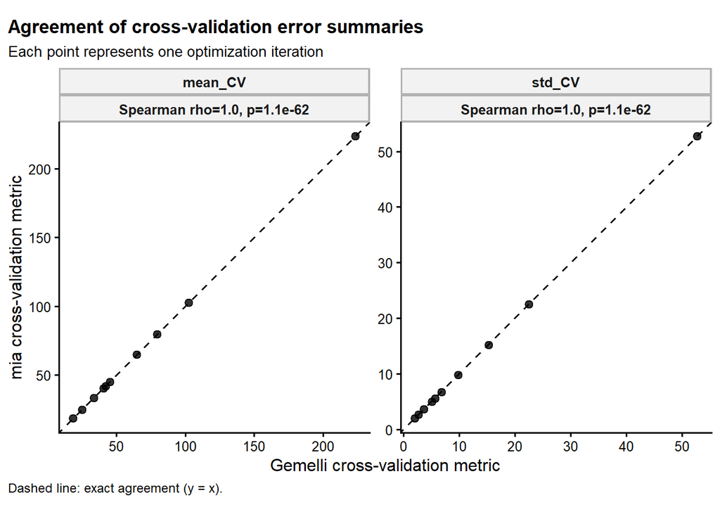

```r
cv_plot_data <- rbind(
  data.frame(
    metric = "mean_CV",
    Python = cv_comparison[["Python mean_CV"]],
    R = cv_comparison[["R mean_CV"]]
  ),
  data.frame(
    metric = "std_CV",
    Python = cv_comparison[["Python std_CV"]],
    R = cv_comparison[["R std_CV"]]
  )
)

cv_plot_data$panel <- ave(
  seq_len(nrow(cv_plot_data)),
  cv_plot_data$metric,
  FUN = function(index) {
    rep(
      spearman_label(
        cv_plot_data$Python[index],
        cv_plot_data$R[index]
      ),
      length(index)
    )
  }
)

ggplot(cv_plot_data, aes(x = Python, y = R)) +
  geom_abline(
    intercept = 0,
    slope = 1,
    linewidth = 0.55,
    linetype = "dashed"
  ) +
  geom_point(size = 2.3, alpha = 0.8) +
  facet_wrap(
    vars(metric, panel),
    scales = "free",
    nrow = 1,
    labeller = label_value
  ) +
  labs(
    title = "Agreement of cross-validation error summaries",
    subtitle = "Each point represents one optimization iteration",
    x = "Gemelli cross-validation metric",
    y = "mia cross-validation metric",
    caption = "Dashed line: exact agreement (y = x)."
  ) +
  theme(aspect.ratio = 1)
```

## Distance structure

**Show analysis code**

```r
gemelli_distance <- gemelli_distance[
  rownames(mia_distance),
  colnames(mia_distance),
  drop = FALSE
]

upper_index <- upper.tri(mia_distance, diag = FALSE)

distance_correlation <- cor(
  mia_distance[upper_index],
  gemelli_distance[upper_index]
)

distance_comparison <- data.frame(
  Metric = "Pearson correlation",
  Value = distance_correlation
)

knitr::kable(
  distance_comparison,
  digits = 6,
  caption = "Agreement between pairwise sample-distance matrices",
  align = c("l", "r")
)
```

Agreement between pairwise sample-distance matrices

| Metric | Value |
| --- | --- |
| Pearson correlation | 1 |

**Show analysis code**

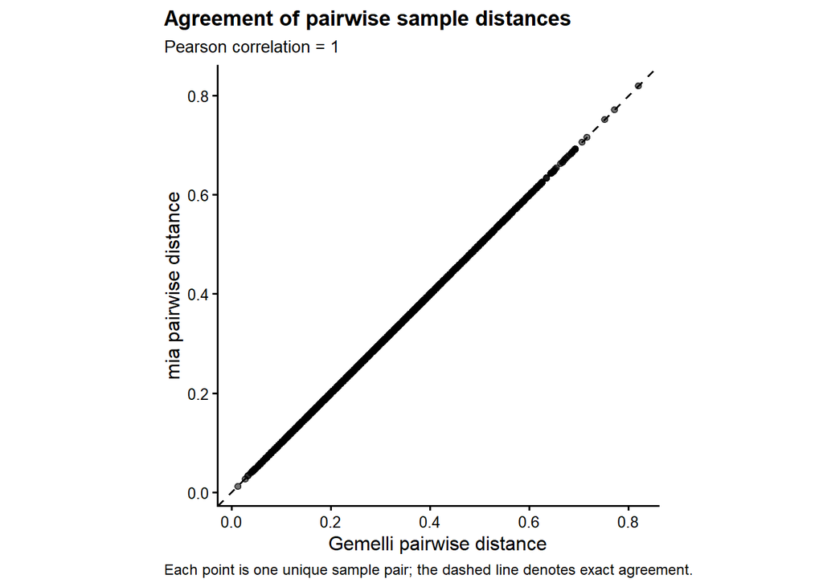

```r
distance_plot_data <- data.frame(
  Gemelli = gemelli_distance[upper_index],
  mia = mia_distance[upper_index]
)

ggplot(distance_plot_data, aes(x = Gemelli, y = mia)) +
  geom_abline(
    intercept = 0,
    slope = 1,
    linewidth = 0.55,
    linetype = "dashed"
  ) +
  geom_point(size = 1.5, alpha = 0.55) +
  coord_equal() +
  labs(
    title = "Agreement of pairwise sample distances",
    subtitle = paste0(
      "Pearson correlation = ",
      format(distance_correlation, digits = 6)
    ),
    x = "Gemelli pairwise distance",
    y = "mia pairwise distance",
    caption = paste(
      "Each point is one unique sample pair;",
      "the dashed line denotes exact agreement."
    )
  )
```

# Main findings

**Show analysis code**

```r
overall_summary <- data.frame(
  Quantity = c(
    "Minimum sample-score correlation",
    "Minimum feature-loading correlation",
    "Maximum explained-variation difference",
    "Distance-matrix correlation"
  ),
  Value = c(
    min(pc_correlations),
    min(feature_loading_correlations),
    max(explained_variance_comparison$`Absolute difference`),
    distance_correlation
  ),
  stringsAsFactors = FALSE
)

knitr::kable(
  overall_summary,
  digits = 8,
  caption = "Numerical summary of cross-implementation agreement",
  align = c("l", "r")
)
```

Numerical summary of cross-implementation agreement

| Quantity | Value |
| --- | --- |
| Minimum sample-score correlation | 1e+00 |
| Minimum feature-loading correlation | 1e+00 |
| Maximum explained-variation difference | 1e-08 |
| Distance-matrix correlation | 1e+00 |

# Session information

**Show analysis code**